# InVivoStat Linear Regression Analysis

## Response and covariate

The Resp11 response is currently being analysed by the Linear Regression Analysis module, with Covariate2 fitted as a covariate.

## Scatterplots of the observed data, including best-fit regression lines

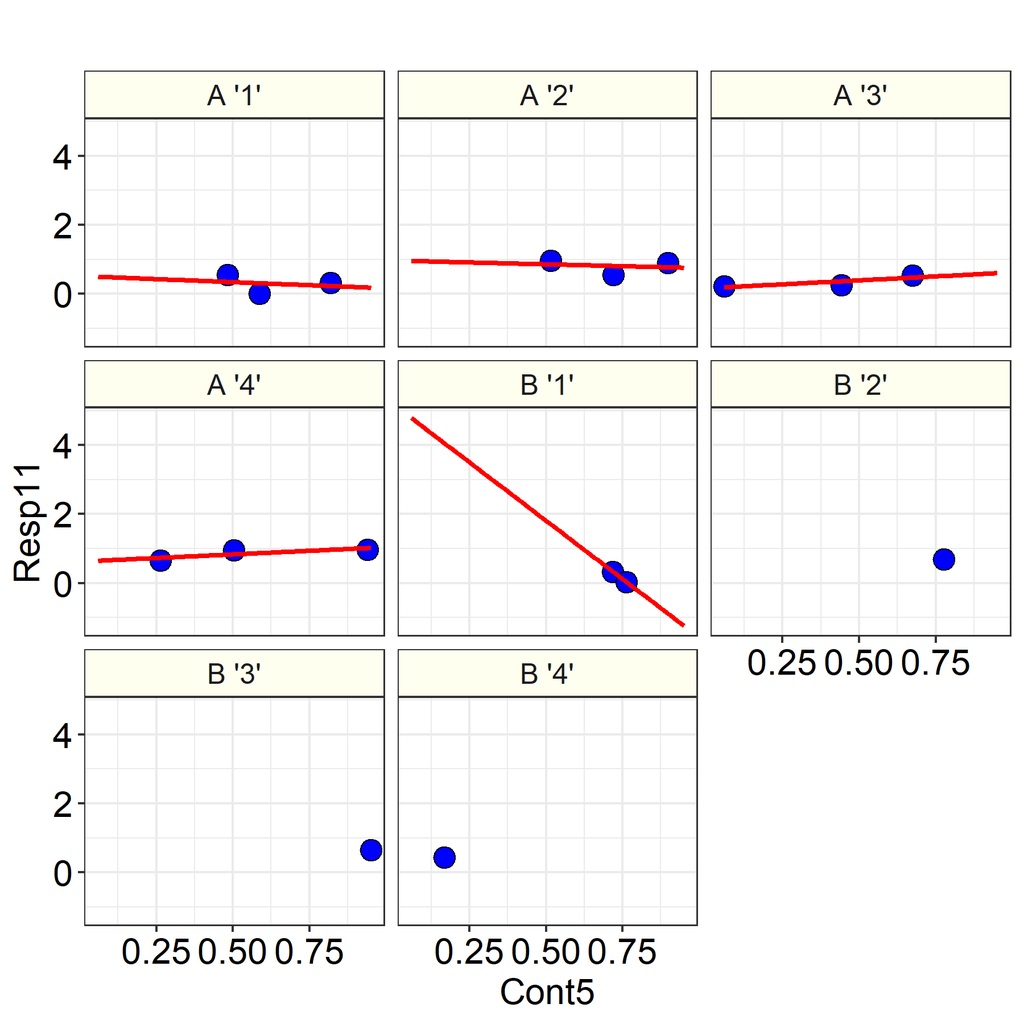

Note: The best-fit regression lines included on the plot are not adjusted for the covariate.

## Estimates of the coefficients of the best-fit regression lines

| Categorisation factor level combinations | Intercept estimate | Slope estimate |
| --- | --- | --- |
| A '1' | 0.5137 | -0.3533 |
| A '2' | 0.9626 | -0.2182 |
| A '3' | 0.1602 | 0.4586 |
| A '4' | 0.6215 | 0.4186 |
| B '1' | 5.1934 | -6.7649 |
| B '2' | - | - |
| B '3' | - | - |
| B '4' | - | - |

Note: The estimates of the regression coefficients are not adjusted for the covariate.

## Plot of the response vs. the covariate, categorised by the primary factor

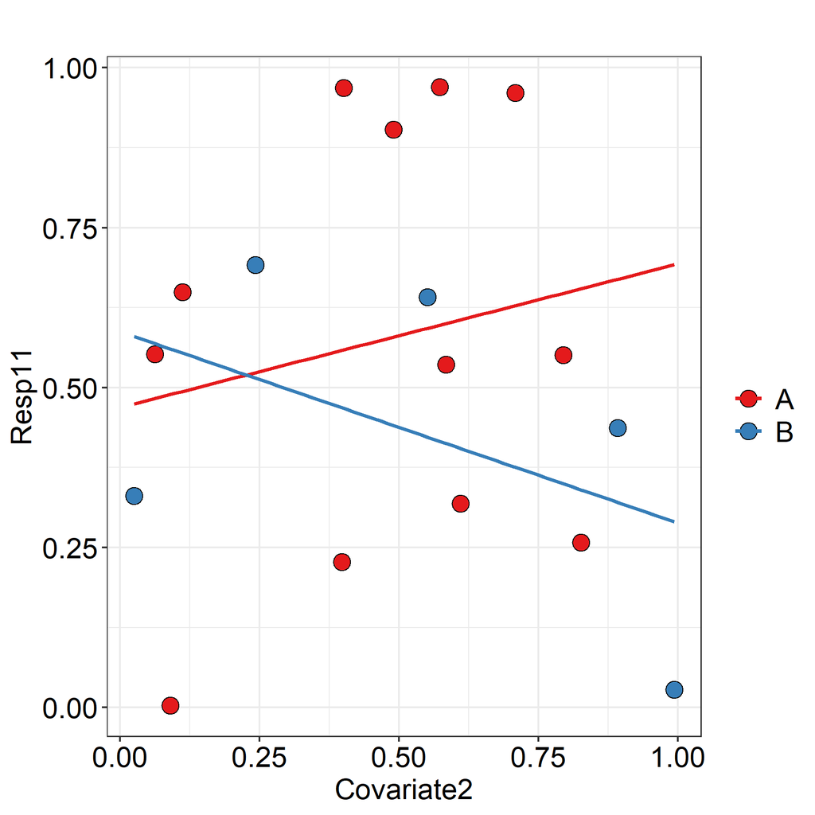

Tip: In order to decide whether it is helpful to fit the covariate, the following should be considered:

a) Is there a relationship between the response and the covariate? (N.B., It is only worth fitting the covariate if there is a strong positive (or negative) relationship between them: i.e., the lines on the plot should not be horizontal).

b) Is the relationship similar for all levels of the categorical factor? (The lines on the plot should be approximately parallel).

c) Is the covariate influenced by the categorisation factor? (We assume the covariate is not influenced by the categorisation factor and so there should be no separation of the categorisation factor levels along the x-axis on the plot).

These issues are discussed in more detail in Morris (1999).

## Analysis of Covariance (ANCOVA) table for assessing covariate interactions

The covariate interactions have not been calculated as there are zero residual degrees of freedom, or the residual sums of squares is close to zero, when all terms are included in the statistical model.

## Analysis of Covariance (ANCOVA) table

#### Error

Unfortunately there are aliased parameters in the statistical model. This can be caused if a best-fit regression line cannot be fitted for one or more combinations of the categorical factor levels in the above scatterplots. In order to perform an analysis, the model may need to be simplified.